# Análisis de datos con RStudio - Proyecto BACI

2025-04-10

# Análisis de datos con RStudio - Proyecto BACI

Los datos provistos por **BACI** nos muestran los flujos de intercambios realizados por dos países, en el cual intervienen cantidades y valores monetarios e información de la transacción de los más de 5000 productos validados por *“Harmonized System”*.

```r
#limpio la memoria
rm( list=ls())  #remove all objects
gc()             #garbage collection
```

```
##          used (Mb) gc trigger (Mb) max used (Mb)
## Ncells 543274 29.1    1208981 64.6   686460 36.7
## Vcells 994668  7.6    8388608 64.0  1876177 14.4
```

```r
# Seteo mismo wd para todos los chunks
#knitr::opts_knit$set(root.dir = "~/Curso-R-Escuela-de-Verano-UNGS")
#knitr::opts_knit$set(root.dir = "~")
```

```r
require(dplyr)
require(ggplot2)
require(purrr)
require(readr)
require(readxl)
require(data.table)
require(scales)
```

## Preparación de los datos

Establecemos la ruta de nuestros archivos

```r
# Damos la ruta de nuestra carpeta de archivos
folder.path <- "../fuentes"

# Listamos los archivos que hay allí, todos no, los que nos interesan.
bases.baci <- list.files(path = folder.path, pattern = "BACI.*", recursive = T, full.names = T)

#bases.baci
```

Creamos una función `'buscar.archivo.pro'` que me busque archivos de la carpeta que elegiremos más adelante. También haremos uso de la función `'buscar.archivo.simple'` para no imprimir por consola que el archivo ha sido encontrado.

```r
# Función que me muestra si encontró o no la carpeta

buscar.archivo.pro <- function(anio,hs){
  pattern = sprintf("*BACI_HS%s_Y%s.*", hs, anio)
  archivo.selec <- bases.baci[grepl(pattern = pattern, bases.baci )]

  if (length(archivo.selec)==0){
    failure <- sprintf("No se encontró archivo para el año %s y HS%s", anio, hs)
    print(failure)
    return(NA)
  }
  else{
    success <- sprintf("El archivo para el año %s y HS%s ha sido encontrado", anio, hs)
    print(success)
  return(archivo.selec)
  }
}

# Esta función la usamos sabiendo que el archivo esta presente y no imprime por consola que la encontró

buscar.archivo.simple <- function(anio,hs){
  pattern = sprintf("*BACI_HS%s_Y%s.*", hs, anio)
  archivo.selec <- bases.baci[grepl(pattern = pattern, bases.baci )]
  return(archivo.selec)
}
```

Vamos a utilizar una primera aproximación al problema, **buscando las versiones disponibles que tenemos en nuestro filesystem**. Luego se muestran y elegiremos una de ellas

```r
buscar.versiones <- function(b.baci) {
  vers <- c(substring(b.baci[1], 19, 20))

  for (i in 2:length(b.baci)){
    v <- substring(b.baci[i], 19, 20)
    vers <- c(vers, v)
  }
  return(unique(vers))
}

versiones.total <- buscar.versiones(bases.baci)
versiones.total
```

```
## [1] "12" "17" "22"
```

Elegimos una de ellas y averiguamos que años dispone para usarlo en nuestro estudio, guardamos esa información en un vector. Guardamos además, los años de la versión elegida en un vector.

```r
####### Carga de datos ########
version <- c('12')
###############################

buscar.anios <- function(vers, b.baci) {
  as <- c()

  for (i in 1:length(bases.baci)){
  if(substring(bases.baci[i], 19, 20) == vers) {
    a <- substring(bases.baci[i], 41, 44)
    as <- c(as, a)
    }
  }
  return(as)
}

anios <- buscar.anios(version, bases.baci)
anios
```

```
##  [1] "2012" "2013" "2014" "2015" "2016" "2017" "2018" "2019" "2020" "2021"
## [11] "2022" "2023"
```

## Carga de datos

Para comenzar el ánalisis vamos a cargar los dataframes (df) para la `version` elegido.

```r
# Código para cargar los dataframes (df) de todos los años, el último "df" queda en el último año. Imprime todos los df encontrados.

# Itero sobre las versiones
for (v in version){

  # Itero sobre los años
  for (a in anios){

    # Busco archivo
    archivo <- buscar.archivo.pro(anio = a, hs=v)

    # Si no es NA hago algo.
    if (!is.na(archivo)){

      # Llevo la versión a "HS.." para que quede completo.
      vers <- paste0("HS",v)

       # Leo el archivo, casteo la columna k como caracter, elimino el verbose y además le digo que me devuelva un data.frame y no un data.table. Todo eso con el método fread de data.table

      df <- fread(archivo, colClasses = c("k"="character"), showProgress = F, data.table = F)

      # Creo un df para renombrar las columnas
      df.names <- df

      colnames(df.names)<-c('Año','Exportador','Importador','Producto','Valor','Cantidad')
    }
  }
}
```

```
## [1] "El archivo para el año 2012 y HS12 ha sido encontrado"
## [1] "El archivo para el año 2013 y HS12 ha sido encontrado"
## [1] "El archivo para el año 2014 y HS12 ha sido encontrado"
## [1] "El archivo para el año 2015 y HS12 ha sido encontrado"
## [1] "El archivo para el año 2016 y HS12 ha sido encontrado"
## [1] "El archivo para el año 2017 y HS12 ha sido encontrado"
## [1] "El archivo para el año 2018 y HS12 ha sido encontrado"
## [1] "El archivo para el año 2019 y HS12 ha sido encontrado"
## [1] "El archivo para el año 2020 y HS12 ha sido encontrado"
## [1] "El archivo para el año 2021 y HS12 ha sido encontrado"
## [1] "El archivo para el año 2022 y HS12 ha sido encontrado"
## [1] "El archivo para el año 2023 y HS12 ha sido encontrado"
```

```r
#df.names
head(df.names)
```

```
##    Año Exportador Importador Producto  Valor Cantidad
## 1 2023          4         20   200290  8.013    5.830
## 2 2023          4         24   252220 21.928   64.909
## 3 2023          4         24   293629  0.128    0.004
## 4 2023          4         24   330300  0.738    0.296
## 5 2023          4         24   330499  0.387    0.048
## 6 2023          4         24   420299  0.734    0.023
```

Ésta última tabla corresponde al último año de la versión en estudio

En la [documentación](http://www.cepii.fr/DATA_DOWNLOAD/baci/doc/DescriptionBACI.html) de BACI se puede ver qué es cada columna:

- t : año (dbl)
- k: código HS de producto (chr)
- i : código país exportador (dbl)
- j: código país importador (dbl)
- v: valor comercializado en miles de USD (dbl)
- q: toneladas comercializadas (dbl)

Renombramos cada columna para una mejor visualización

## Análisis de los datos

Asignamos a cada producto `k` su descripción provisto por el la variable `codes.productos`

```r
# Según que fecha se hayan descargados los archivos es probable que tuviesen una versión distinta. Lo averiguamos en la siguiente línea de código

ver.folder <- substring(bases.baci[1], 46, 52)
#ver.folder

# Luego lo usamos para cargar nuevos archivos donde están las descripciones

folder.path.prod = sprintf("../fuentes/BACI_HS%s_%s/product_codes_HS%s_%s.csv", version, ver.folder, version, ver.folder)

# Cargamos códigos de los productos

codes.productos <- read_csv(folder.path.prod, show_col_types = F)

# Vemos cuantos valores distintos tenemos de 'k'

product_names <- df %>%
                 distinct(k) %>%
                 left_join(.,codes.productos , by = c(k="code")) %>%
                 select(k, description)

product.names <- product_names

colnames(product.names)<-c('Cod.','Descripción')

#product.names
head(product.names)
```

```
##     Cod.
## 1 200290
## 2 252220
## 3 293629
## 4 330300
## 5 330499
## 6 420299
##                                                                                                                                                   Descripción
## 1                           Vegetable preparations: tomatoes, (other than whole or in pieces), prepared or preserved otherwise than by vinegar or acetic acid
## 2                                                                                      Slaked lime: excluding calcium oxide and hydroxide of heading no. 2825
## 3                                                                                         Vitamins: n.e.c. in item no. 2936.2, and their derivatives, unmixed
## 4                                                                                                                                  Perfumes and toilet waters
## 5 Cosmetic and toilet preparations: n.e.c. in heading no. 3304, for the care of the skin (excluding medicaments, including sunscreen or sun tan preparations)
## 6           Cases and containers: n.e.c. in heading 4202, of vulcanised fibre or of paperboard, or wholly or mainly covered with such materials or with paper
```

### Venta total de cada producto visto para cada año.

```r
tabla.suma.by.k <- function(versiones, ans){

  # Defino un data.frame vacío.
  tabla_sum_anios <- data.frame()

  # Itero sobre las versiones
  for (versions in versiones){

    # Itero sobre los anios
    for (an in ans){

        # Busco archivo
      archivo <- buscar.archivo.simple(anio = an, hs=versions)

      df <- fread(archivo, colClasses = c("k"="character"), showProgress = F,
                    data.table = F)

         # Agrupamos por porduct (k) y sumamos

      suma_value <- df %>% group_by(t,k) %>%
                      summarise(sum_v = sum(v, na.rm = T),  .groups = 'drop')

        # Anadimos a un dataframe la suma de todos los productos agrupados por cada año en un en un solo dataframe.

      tabla_sum_anios <- rbind(tabla_sum_anios, suma_value)
    }
  }

  return(tabla_sum_anios)

}

k_sum_prod <- tabla.suma.by.k(version, anios) %>%
              left_join(.,codes.productos , by = c(k="code"))

k_sum_prod.names <- k_sum_prod

colnames(k_sum_prod.names)<-c('Año','Cod. Producto','Sum. Exp.','Descripción')

#k_sum_prod.names
head(k_sum_prod.names)
```

```
## # A tibble: 6 × 4
##     Año `Cod. Producto` `Sum. Exp.` Descripción
##   <int> <chr>                 <dbl> <chr>
## 1  2012 010121             1166505. Horses: live, pure-bred breeding animals
## 2  2012 010129              948005. Horses: live, other than pure-bred breeding…
## 3  2012 010130                3176. Asses: live
## 4  2012 010190               40006. Mules and hinnies: live
## 5  2012 010221             1438843. Cattle: live, pure-bred breeding animals
## 6  2012 010229             6260329. Cattle: live, other than pure-bred breeding…
```

Podríamos estar interesados, por ejemplo, en la evolución de un producto a lo largo de los años, realizamos un gráfico para comprender su evolución.

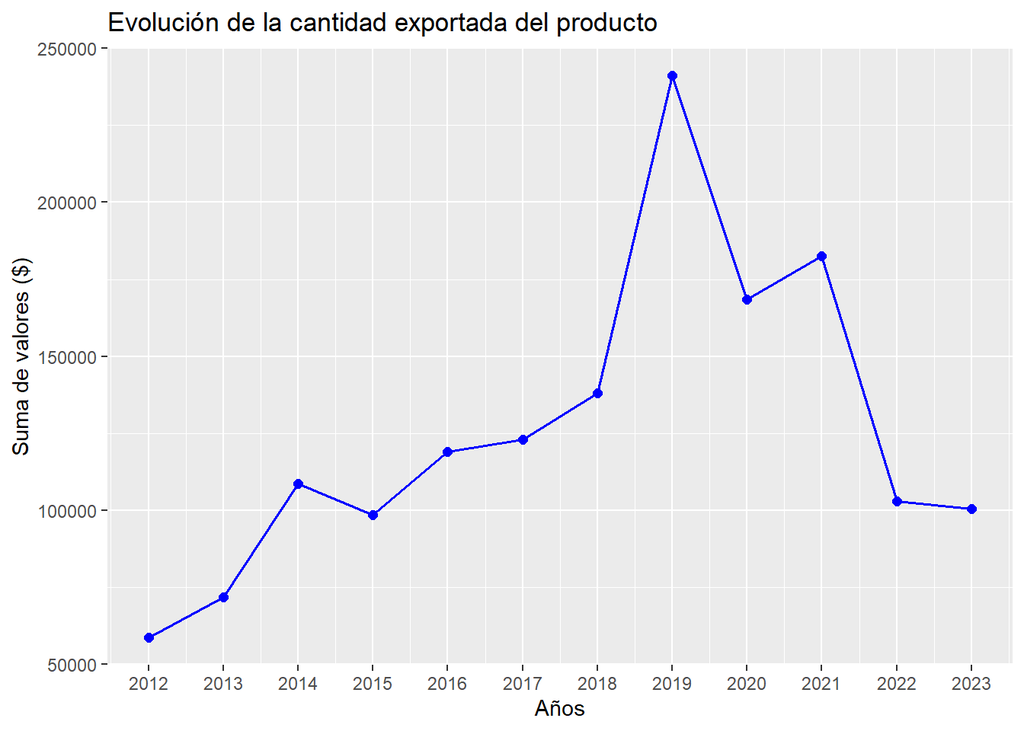

```r
####### Carga de datos ########
codigo <- '010239'
###############################

# Graficamos la evolución de un la suma de cantidades para un producto (k) específico

graf_k <- k_sum_prod %>% filter(k == codigo) %>%
  ggplot(aes(x = t, y = sum_v)) + geom_line(color="blue", size=0.7)+
  geom_point(color="blue", size=2) +
  labs(title = "Evolución de la cantidad exportada del producto") +
  xlab("Años") + ylab("Suma de valores ($)") +
  scale_x_continuous(breaks = seq(2012, 2023, by = 1))
graf_k
```

### ¿Cuáles fueron los 5 productos más vendidos durante el período de años?

```r
top_5_prod <- k_sum_prod %>% group_by(k) %>%
              summarise(s = sum(sum_v, na.rm = T)) %>%
  arrange(-s) %>%
  head(k_sum_prod, n = 5L) %>%
  left_join(.,codes.productos , by = c(k="code")) %>%
  select(k, description, s)

top_5_prod.name <- top_5_prod

colnames(top_5_prod.name) <- c('Producto','Descripción','Suma Valores')

top_5_prod.name
```

```
## # A tibble: 5 × 3
##   Producto Descripción                                            `Suma Valores`
##   <chr>    <chr>                                                           <dbl>
## 1 270900   Oils: petroleum oils and oils obtained from bituminou…   14143783098.
## 2 271000   Petroleum oils and oils from bituminous minerals, not…    9274252323.
## 3 710812   Metals: gold, non-monetary, unwrought (but not powder)    3965867732.
## 4 300490   Medicaments: consisting of mixed or unmixed products …    3572882920.
## 5 851712   Telephones for cellular networks or for other wireles…    3434792363.
```

Vamos a elaborar un dataframe donde se muestre la venta total de para cada producto del top 5 que realizó cada país que realizó exportación

```r
# Cargamos códigos de los países

folder.path.country = sprintf("../fuentes/BACI_HS%s_%s/country_codes_%s.csv", version, ver.folder, ver.folder)

codes.paises <- read_csv(folder.path.country,show_col_types = F)
```

```r
tabla.suma.by.top5k <- function(versiones, ans, top){

  # Itero sobre las versiones
  for (versions in versiones){

    # Defino un data.frame vacío.
    rank_total <- data.frame()

    for (code in top) {

      rank_sum <- data.frame()

      for (an in ans){

        archivo <- buscar.archivo.simple(anio = an, hs=versions)

        df <- fread(archivo, colClasses = c("k"="character"), showProgress = F,
                  data.table = F)

       # Agrupamos para un producto 'k' (del top 5) y sumamos -> sum_v_code
        rank_code <- df %>%
          filter(k == code) %>%
          group_by(i,t) %>%
          summarise(sum_v_code =  sum(v, na.rm = T),  .groups = 'drop')

        # Añadimos año por año
        rank_sum <- rbind(rank_sum, rank_code)

      }
      # Añadimos la columna para el k iterado
      rank_sum <- cbind(rank_sum, c(code))

      # Añadimos a los de mas k (códigos de los productos)
      rank_total <- rbind(rank_total, rank_sum)
    }
  }
  return(rank_total)
}

# Obtenemos la siguiente tabla

sum_anio_byk <- tabla.suma.by.top5k (version, anios, top_5_prod$k) %>% rename('k' = 'c(code)')
```

A continuación mostramos el top 10 de países que exportaron en mayor cantidad los productos del top 5. Además anexamos en un gráfico la evolución que tuvieron en todos los años

```
## [1] "El producto *Oils: petroleum oils and oils obtained from bituminous minerals, crude* cuyo código es *270900*, tiene el siguiente top 10 de paises que más vendieron"
##
## # A tibble: 10 × 3
##    `Cod. País` País                 `Suma  de Valores ($)`
##          <dbl> <chr>                                 <dbl>
##  1         682 Saudi Arabia                    2434069304.
##  2         643 Russian Federation              1503568383.
##  3         784 United Arab Emirates            1007336515.
##  4         368 Iraq                             916693193.
##  5         124 Canada                           888762231.
##  6         566 Nigeria                          594455830.
##  7         414 Kuwait                           590248355.
##  8         842 USA                              539867931.
##  9         579 Norway                           471914413.
## 10          24 Angola                           462710316.
```

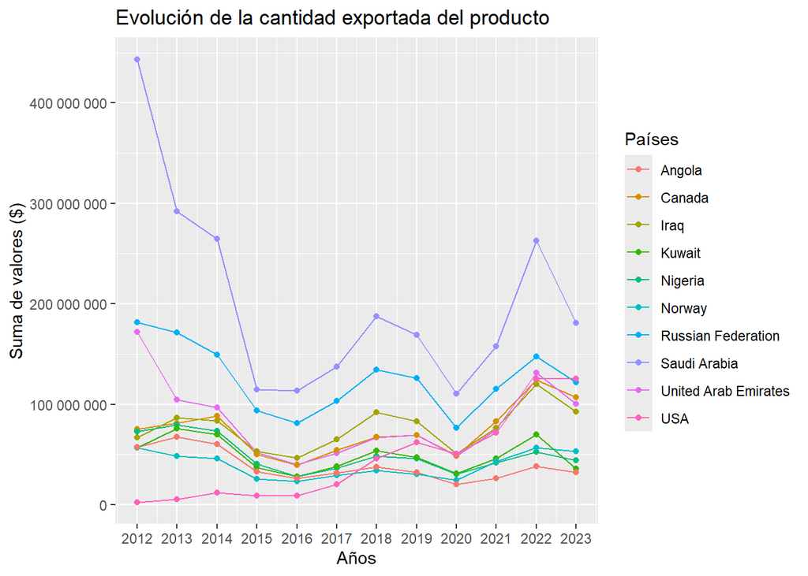

```
## [1] "El producto *Petroleum oils and oils from bituminous minerals, not crude: preparations n.e.c. containing by weight 70% or more of petroleum oils or oils from bituminous minerals: these being the basic constituents of the preparations: waste oils* cuyo código es *271000*, tiene el siguiente t…
##
## # A tibble: 10 × 3
##    `Cod. País` País                 `Suma  de Valores ($)`
##          <dbl> <chr>                                 <dbl>
##  1         842 USA                             1103520820.
##  2         643 Russian Federation               906521356.
##  3         702 Singapore                        597556005.
##  4         528 Netherlands                      585277561.
##  5         699 India                            528938529.
##  6         410 Rep. of Korea                    484678188.
##  7         784 United Arab Emirates             416028484.
##  8         458 Malaysia                         309623184.
##  9         682 Saudi Arabia                     308492399.
## 10          56 Belgium                          297111196.
```

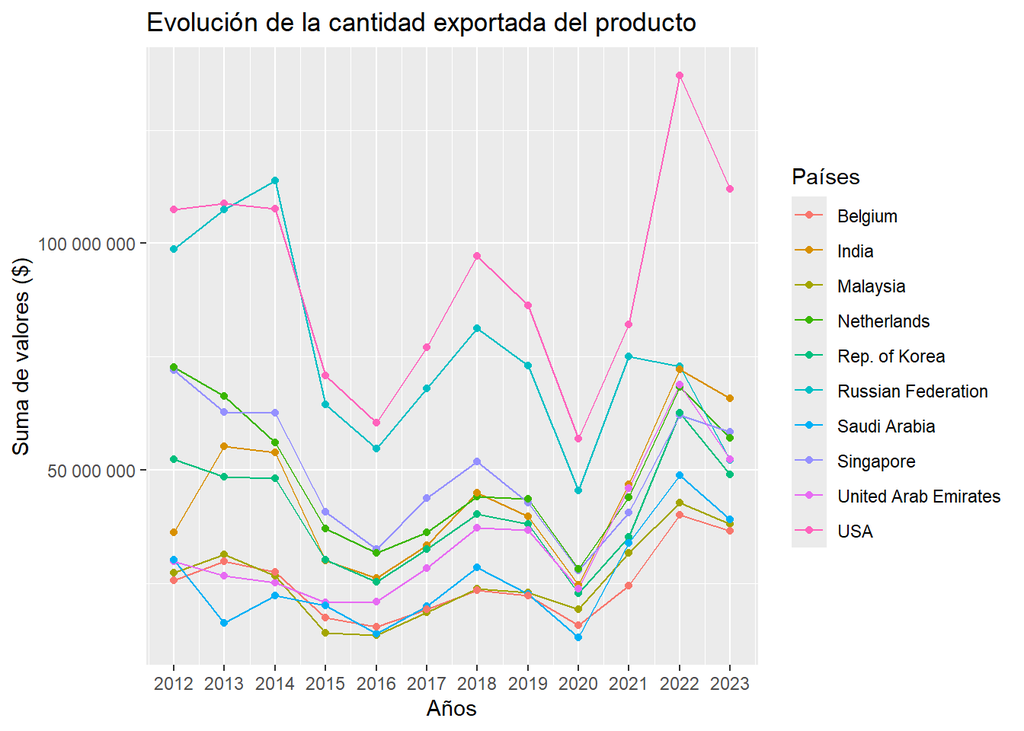

```
## [1] "El producto *Metals: gold, non-monetary, unwrought (but not powder)* cuyo código es *710812*, tiene el siguiente top 10 de paises que más vendieron"
##
## # A tibble: 10 × 3
##    `Cod. País` País                 `Suma  de Valores ($)`
##          <dbl> <chr>                                 <dbl>
##  1         757 Switzerland                      861159844.
##  2         344 China, Hong Kong SAR             300995562.
##  3         784 United Arab Emirates             294103448.
##  4         842 USA                              244194893.
##  5         826 United Kingdom                   190882715.
##  6         710 South Africa                     169155882.
##  7          36 Australia                        161413588.
##  8         124 Canada                           134846114.
##  9         643 Russian Federation                90081050.
## 10         604 Peru                              88725678.
```

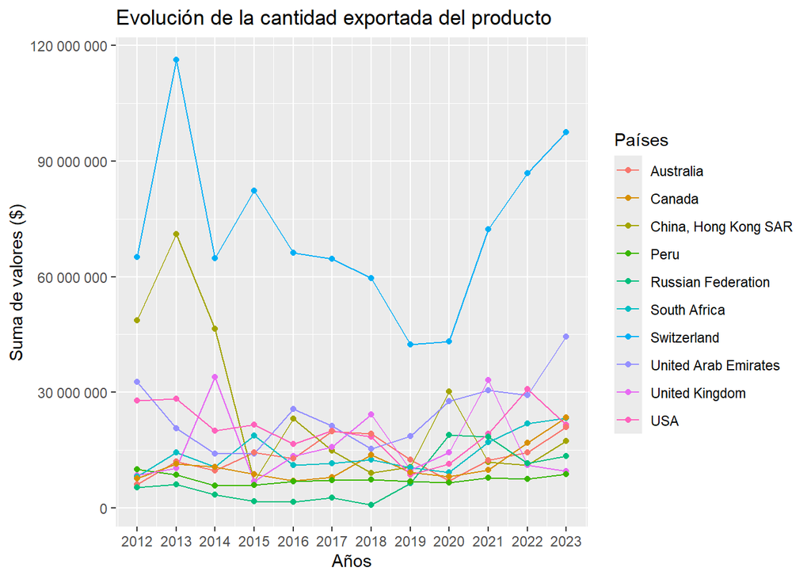

```
## [1] "El producto *Medicaments: consisting of mixed or unmixed products n.e.c. in heading no. 3004, for therapeutic or prophylactic uses, packaged for retail sale* cuyo código es *300490*, tiene el siguiente top 10 de paises que más vendieron"
##
## # A tibble: 10 × 3
##    `Cod. País` País           `Suma  de Valores ($)`
##          <dbl> <chr>                           <dbl>
##  1         276 Germany                    540614975.
##  2         757 Switzerland                409379650.
##  3         842 USA                        338003589.
##  4         372 Ireland                    301993396.
##  5         251 France                     220210156.
##  6         380 Italy                      214073900.
##  7         826 United Kingdom             183307447.
##  8         699 India                      157970162.
##  9          56 Belgium                    151920767.
## 10         528 Netherlands                144977945.
```

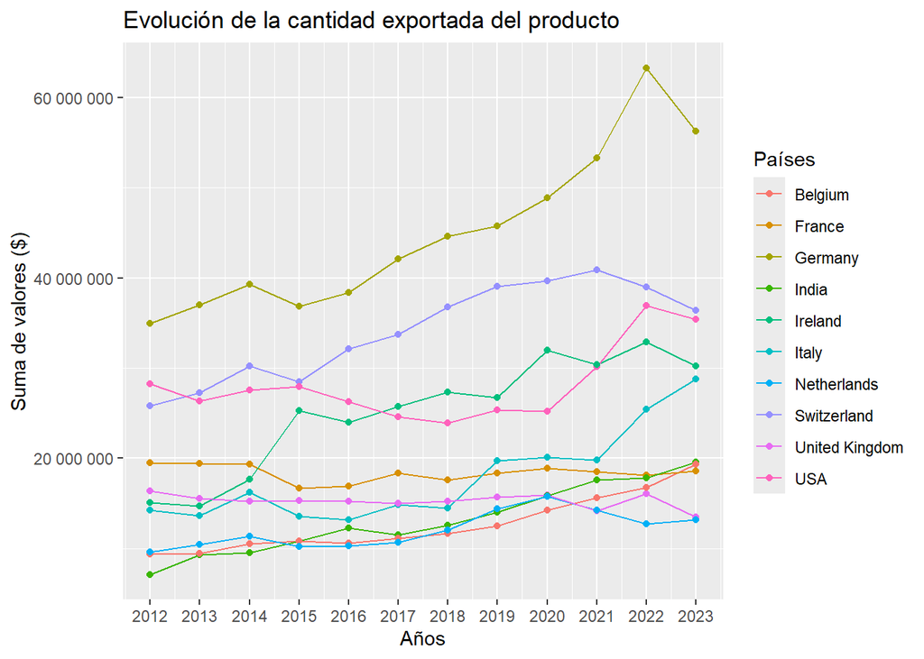

```
## [1] "El producto *Telephones for cellular networks or for other wireless networks* cuyo código es *851712*, tiene el siguiente top 10 de paises que más vendieron"
##
## # A tibble: 10 × 3
##    `Cod. País` País                 `Suma  de Valores ($)`
##          <dbl> <chr>                                 <dbl>
##  1         156 China                           2119863150.
##  2         704 Viet Nam                         419877944.
##  3         410 Rep. of Korea                    124821269.
##  4         784 United Arab Emirates              96767641.
##  5         528 Netherlands                       95157666.
##  6         842 USA                               78421107.
##  7         344 China, Hong Kong SAR              53483254.
##  8         276 Germany                           50276414.
##  9         699 India                             48525419.
## 10         490 Other Asia, nes                   44376073.
```

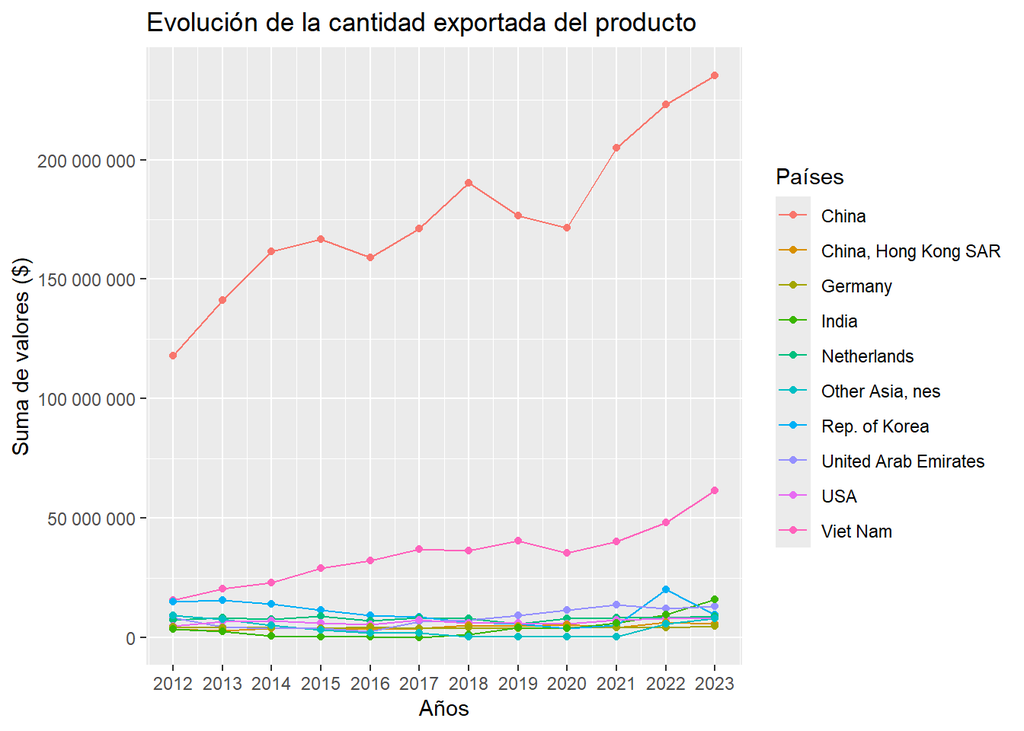

```r
# Función que me devuelve el top 10 para cada 'k' y su evolución en gráfico

tabla.top10.by.k <- function(df_resumen, top){

  #iteramos para cada k
  for (code in top) {

    rank.k <- df_resumen %>% filter(k == code)

    rank.top <- rank.k %>% group_by(i) %>%
      summarise(sum_v = sum(sum_v_code, na.rm = T),  .groups = 'drop') %>%
      arrange(-sum_v) %>% head(rank.k, n=10L) %>%
      left_join(.,codes.paises , by = c(i="country_code")) %>%
      select(i, country_name, sum_v)

    rank.top.names <- rank.top

    colnames(rank.top.names)<-c('Cod. País','País', 'Suma  de Valores ($)')

     print(sprintf("El producto *%s* cuyo código es *%s*, tiene el siguiente top 10 de paises que más vendieron", top_5_prod$description[which(top_5_prod$k == code)], top_5_prod$k[top_5_prod$k == code]))

     cat("\n")

    # Imprimimos el top 10
    print(rank.top.names)

    rank.to.graph <- data.frame()

    # Recogemos los paises del top y lo guardamos para luego observar su              evolución
    for (id in rank.top$i) {

      rank.k.i <- rank.k %>%
        filter(rank.k$i== id) %>%
        left_join(.,codes.paises , by = c(i="country_code")) %>%
        select(k, country_name, t, sum_v_code)

      rank.to.graph <- rbind(rank.to.graph, rank.k.i)
      }

    # Mostramos la grafica para cada producto (k)
    graph.k.i.t <- ggplot(rank.to.graph, aes(t, sum_v_code, group=country_name, colour=country_name)) +
      geom_line() + geom_point() +
      labs(title = "Evolución de la cantidad exportada del producto") +
      xlab("Años") +  ylab("Suma de valores ($)") + scale_x_continuous(breaks = seq(2012, 2023, by = 1)) +
      scale_y_continuous(labels = label_number()) +
      guides(color = guide_legend(title = "Países"))

    print(graph.k.i.t)
  }
}

# Top 10 de países y su evolución en el período de años

rank_top10_k <- tabla.top10.by.k(sum_anio_byk, top_5_prod$k)
```

### Participación de un país con los productos del top 5.

```r
#Buscamos la posición del país elegido en el dataframe codes.paises

####### Carga de datos ########
country <- 'Peru'
year <- 2017
##############################

#Buscamos su posición
pos_country <- which(codes.paises$country_name == country)

#Función que me permite ver la participación del país elegido con el top 5 de productos

tabla.country.by.k <- function(df_resumen, top){

  df_country <- data.frame()

  #iteramos para cada k
  for (code in top) {

    tabla.by.k<- df_resumen %>%
      filter(k==code, i==codes.paises$country_code[pos_country], t==year) %>%
      group_by(i, k) %>% summarise(sum_v_code = sum(sum_v_code, na.rm = T) , .groups = 'drop')

    # Anexamos
    df_country <- rbind(df_country, tabla.by.k)
  }
    df_country <- df_country %>%
      left_join(.,codes.productos , by = c(k="code")) %>%
      select(i, k, description, sum_v_code)

    return(df_country)
}

# Nos queda el total de ventas que vendió el país elegido para cada producto en el período de años

df_country <- tabla.country.by.k(sum_anio_byk, top_5_prod$k)

df_country.name <- df_country

colnames(df_country.name) <- c('Cod. País','Producto','Descripción','Sum. Val. Export.')

print(sprintf('Suma de valores exportados por *%s* para cada producto del top 5 en todos los años', country))
```

[output not shown]

```r
df_country.name
```

```
## # A tibble: 5 × 4
##   `Cod. País` Producto Descripción                           `Sum. Val. Export.`
##         <int> <chr>    <chr>                                               <dbl>
## 1         604 270900   Oils: petroleum oils and oils obtain…              24915.
## 2         604 271000   Petroleum oils and oils from bitumin…            2571669.
## 3         604 710812   Metals: gold, non-monetary, unwrough…            7135570.
## 4         604 300490   Medicaments: consisting of mixed or …              32114.
## 5         604 851712   Telephones for cellular networks or …               8698.
```

La función `tabla.comp.each.k` compara la exportación de un producto (del top 5) para un determinado país con los países del top 10 para un determinado año elegido anteriormente, dicha comparación lo hace en forma porcentual.

```r
tabla.comp.each.k <- function(df_resumen, top, df_c){

  #iteramos para cada k
  for (code in top) {

    rank.k <- df_resumen %>% filter(k == code, t == year)

    rank.top <- rank.k %>% group_by(i) %>%
      summarise(sum_v = sum(sum_v_code, na.rm = T),  .groups = 'drop') %>%
      arrange(-sum_v) %>%
      head(rank.k, n=10L) %>%
      left_join(.,codes.paises , by = c(i="country_code")) %>%
      select(i, country_name, sum_v)

     print(sprintf("Comparación  en porcentaje de la venta que realizó *%s* del producto *%s* cuyo código es *%s* con los países en el top 10 durante el año *%s*", country, top_5_prod$description[which(top_5_prod$k == code)], code, year))

    # Buscamos la posición del 'k' para tomar su respectivo sum_v_code
    pos <- which(df_c$k == code)

    rank.top.w.percent <- rank.top %>%
      mutate('%' = df_c$sum_v_code[pos]/sum_v*100)
    rank.top.w.percent.name <- rank.top.w.percent

    colnames(rank.top.w.percent.name) <- c('Cod. País','País Top5','Sum. Export.', 'Porcentaje (%)')

    # Imprimimos
    print(rank.top.w.percent.name)
    cat("\n")
  }
}

# Top 10 de países y su evolución
tabla_comp.name <- tabla.comp.each.k(sum_anio_byk, top_5_prod$k, df_country)
```

```
## [1] "Comparación  en porcentaje de la venta que realizó *Peru* del producto *Oils: petroleum oils and oils obtained from bituminous minerals, crude* cuyo código es *270900* con los países en el top 10 durante el año *2017*"
## # A tibble: 10 × 4
##    `Cod. País` `País Top5`          `Sum. Export.` `Porcentaje (%)`
##          <dbl> <chr>                         <dbl>            <dbl>
##  1         682 Saudi Arabia             137668087.           0.0181
##  2         643 Russian Federation       103522122.           0.0241
##  3         368 Iraq                      65155609.           0.0382
##  4         124 Canada                    54385015.           0.0458
##  5         784 United Arab Emirates      51181334.           0.0487
##  6         364 Iran                      44027672.           0.0566
##  7         414 Kuwait                    38288077.           0.0651
##  8         566 Nigeria                   36327020.           0.0686
##  9          24 Angola                    31447752.           0.0792
## 10         579 Norway                    29525754.           0.0844
##
```

[output cut: 59 more lines]

Consideremos las regiones para nuestro estudio, es decir los continentes

```r
# Cargamos csv de las regiones
folder.path.r <- "../src/UNSD — Methodology.csv"

codes.regiones <- read_csv(folder.path.r,show_col_types = F)

#Pasamos a numérico
codes.regiones$`M49 Code` <- as.numeric(codes.regiones$`M49 Code`)
#class(codes.regiones$`M49 Code`)

# Seleccionamos las columnas que nos interesan
codes.regiones <-codes.regiones %>% select("Region Code", "Region Name", "M49 Code", "Country or Area")

nombres_regiones <- c(codes.regiones %>% select("Region Name") %>% distinct())

codes.regiones
```

```
## # A tibble: 248 × 4
##    `Region Code` `Region Name` `M49 Code` `Country or Area`
##    <chr>         <chr>              <dbl> <chr>
##  1 002           África                12 Argelia
##  2 002           África               818 Egipto
##  3 002           África               434 Libia
##  4 002           África               504 Marruecos
##  5 002           África               729 Sudán
##  6 002           África               788 Túnez
##  7 002           África               732 Sáhara Occidental
##  8 002           África                86 Territorio Británico del Océano Índico
##  9 002           África               108 Burundi
## 10 002           África               174 Comoras
## # ℹ 238 more rows
```

### Top 5 de productos exportados (en valores y cantidades) por región para cada año.

La función `tabla.suma.v.by.k` para obtener la suma de los valores exportados `sum_v` para cada código `k` por cada país considerando todos los años.

```r
tabla.suma.v.by.k <- function(version, ans){

  tabla_sum_anios <- data.frame()

  for (vers in version){

    for (an in ans){

      archivo <- buscar.archivo.simple(anio = an, hs=vers)

      df <- fread(archivo, colClasses = c("k"="character"), showProgress = F,
                    data.table = F)

      # Agrupamos
      suma_value <- df %>%
        group_by(i,t,k) %>%
        summarise(sum_v = sum(v, na.rm = T),  .groups = 'drop')

      # Anadimos a un dataframe la suma  por cada año en un en un solo data frame.
      tabla_sum_anios <- rbind(tabla_sum_anios, suma_value)
    }
  }
  return(tabla_sum_anios)
}

k_sum.v_by.i <- tabla.suma.v.by.k(version, anios) %>% left_join(.,codes.regiones , by = c(i="M49 Code"))
```

La función`tabla.suma.q.by.k` para obtener la suma de las cantidades exportados `sum_q` para cada código `k` por cada pais considerando todos los años.

```r
tabla.suma.q.by.k <- function(version, an){

  tabla_sum_anios <- data.frame()

  for (vers in version){

    for (an in anios){

      archivo <- buscar.archivo.simple(anio = an, hs=vers)

      df <- fread(archivo, colClasses = c("k"="character"), showProgress = F,
                    data.table = F)

      # Agrupamos
      suma_quant <- df %>%
        group_by(i,t,k) %>%
        summarise(sum_q = sum(q, na.rm = T),  .groups = 'drop')

      # Anadimos a un dataframe la suma  por cada año en un en un solo data frame.
      tabla_sum_anios <- rbind(tabla_sum_anios, suma_quant)
    }
  }
  return(tabla_sum_anios)
}

k_sum.q_by.i <- tabla.suma.q.by.k(version, anios) %>%
  left_join(.,codes.regiones , by = c(i="M49 Code"))
```

Iteramos y hallamos el top 5 en valores, para cada año, de los productos exportados para cada una de las cinco regiones .

```
## [1] "Top 5 de productos de la región *África* en valores para cada año"
## # A tibble: 60 × 4
##    Producto Región   Año `Sum Val. Export.`
##    <chr>    <chr>  <int>              <dbl>
##  1 270900   África  2012         257306890.
##  2 710812   África  2012          28591313.
##  3 271000   África  2012          24226087.
##  4 271111   África  2012          22493010.
##  5 271121   África  2012          21024588.
##  6 270900   África  2013         261912038.
##  7 710812   África  2013          33614548.
##  8 271000   África  2013          27915381.
##  9 271111   África  2013          22823476.
## 10 271121   África  2013          18552978.
## # ℹ 50 more rows
```

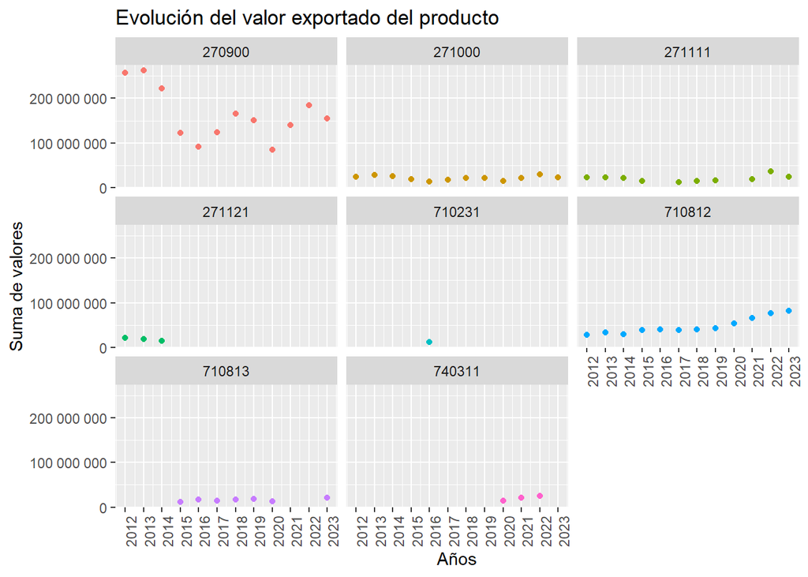

```
## [1] "Top 5 de productos de la región *Américas* en valores para cada año"
## # A tibble: 60 × 4
##    Producto Región     Año `Sum Val. Export.`
##    <chr>    <chr>    <int>              <dbl>
##  1 270900   Américas  2012         241528647.
##  2 271000   Américas  2012          62927201.
##  3 870323   Américas  2012          41444648.
##  4 710812   Américas  2012          40429190.
##  5 870324   Américas  2012          34405896.
##  6 270900   Américas  2013         244947980.
##  7 271000   Américas  2013          59986692.
##  8 870323   Américas  2013          47276332.
##  9 710812   Américas  2013          39009637.
## 10 260111   Américas  2013          34458808.
## # ℹ 50 more rows
```

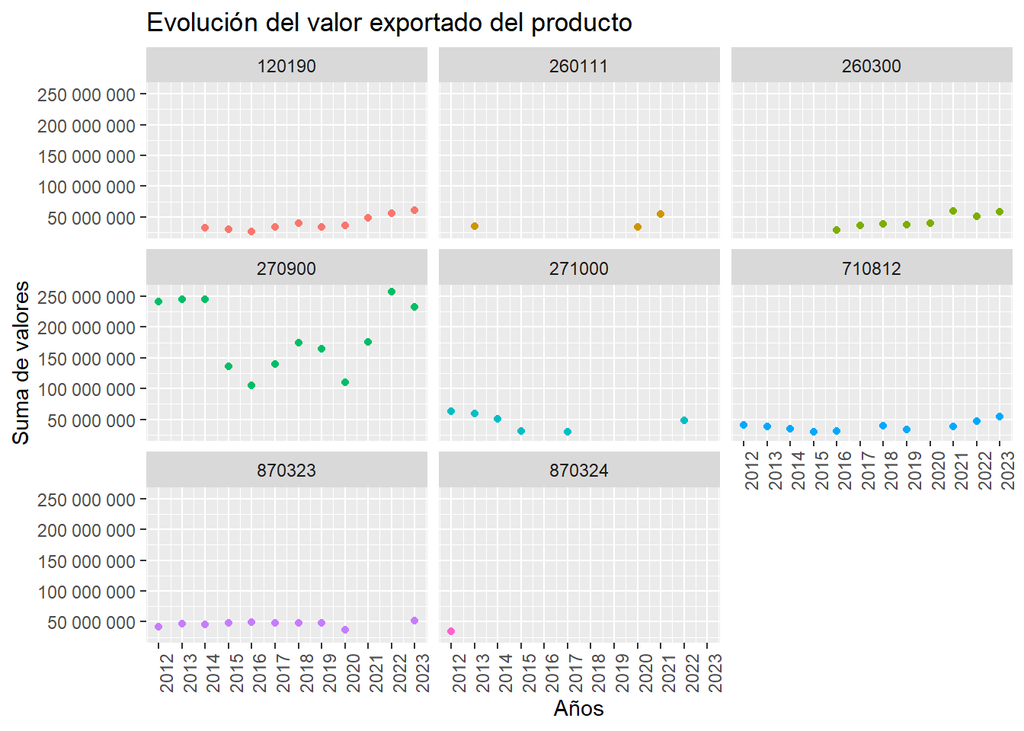

```
## [1] "Top 5 de productos de la región *Asia* en valores para cada año"
## # A tibble: 60 × 4
##    Producto Región   Año `Sum Val. Export.`
##    <chr>    <chr>  <int>              <dbl>
##  1 270900   Asia    2012         967512533.
##  2 271000   Asia    2012         311834757.
##  3 851712   Asia    2012         166589712.
##  4 847130   Asia    2012         145373428.
##  5 710812   Asia    2012         137809644.
##  6 270900   Asia    2013         784419483.
##  7 271000   Asia    2013         294520535.
##  8 851712   Asia    2013         189161474.
##  9 847130   Asia    2013         132602481.
## 10 710812   Asia    2013         129982426.
## # ℹ 50 more rows
```

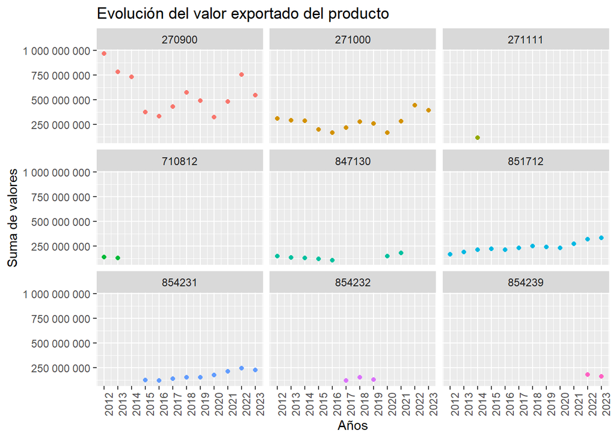

```
## [1] "Top 5 de productos de la región *Europa* en valores para cada año"
## # A tibble: 60 × 4
##    Producto Región   Año `Sum Val. Export.`
##    <chr>    <chr>  <int>              <dbl>
##  1 271000   Europa  2012         376017331.
##  2 270900   Europa  2012         239899507.
##  3 300490   Europa  2012         132361306.
##  4 870332   Europa  2012          94585229.
##  5 870323   Europa  2012          91650081.
##  6 271000   Europa  2013         371662319.
##  7 270900   Europa  2013         228673087.
##  8 300490   Europa  2013         135710096.
##  9 870332   Europa  2013          99783045.
## 10 870323   Europa  2013          99287171.
## # ℹ 50 more rows
```

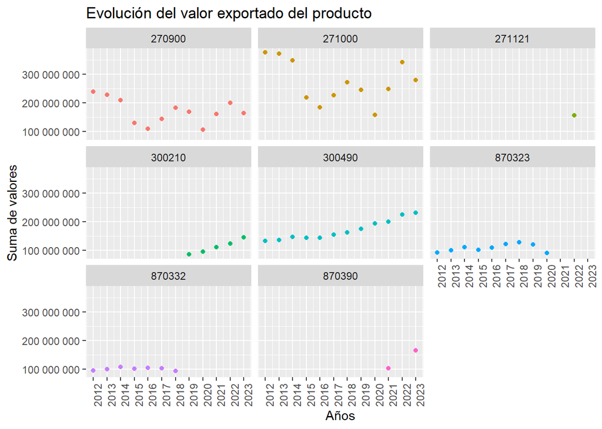

```
## [1] "Top 5 de productos de la región *Oceanía* en valores para cada año"
## # A tibble: 60 × 4
##    Producto Región    Año `Sum Val. Export.`
##    <chr>    <chr>   <int>              <dbl>
##  1 260111   Oceanía  2012          61096598.
##  2 270112   Oceanía  2012          43759012.
##  3 270900   Oceanía  2012          15096712.
##  4 271111   Oceanía  2012          14347225.
##  5 710813   Oceanía  2012          10484311.
##  6 260111   Oceanía  2013          71126763.
##  7 270112   Oceanía  2013          35753273.
##  8 271111   Oceanía  2013          15009359.
##  9 710812   Oceanía  2013          14703621.
## 10 710813   Oceanía  2013          11066817.
## # ℹ 50 more rows
```

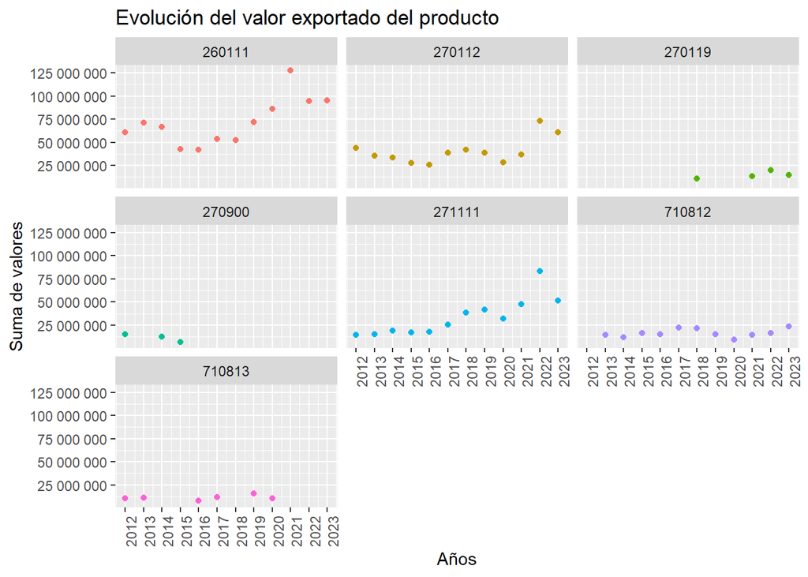

```r
for (nombre in nombres_regiones$`Region Name`){

  tabla.sum.v.by.k.region <- function(sum.v_by.i, nombre, an){

    tabla_top_5_v = data.frame()

    tabla_resumen_v = data.frame()

      if (!is.na(nombre)) {

      for (a in an){

        top_5_value <- sum.v_by.i %>%
          group_by(k, `Region Name`, t) %>%
          filter(`Region Name`== nombre, t == a) %>%
          summarise(sum_values = sum(sum_v, na.rm = T),  .groups = 'drop') %>%
          arrange (-sum_values) %>% head(sum.v_by.i, n=5L)

        # Los unimos en una sola tabla, correspondiente al año presente

          tabla_top_5_v <- rbind(tabla_top_5_v, top_5_value)

      graph.top_5_v <- ggplot(tabla_top_5_v, aes(x=t, y=sum_values, color=k)) +
        geom_point(show.legend = FALSE) +
        facet_wrap(~k) +
        labs(title = "Evolución del valor exportado del producto") +
        xlab("Años") +
        ylab("Suma de valores") + scale_x_continuous(breaks = seq(2012, 2023, by = 1)) + scale_y_continuous(labels = label_number()) +
        theme(axis.text.x = element_text(angle = 90 ))

        resumen_top_5_value <- top_5_value %>%
          group_by(`Region Name`) %>%
          summarise(mean_values = mean(sum_values, na.rm = T))

        resumen_top_5_value <- cbind(c(a), resumen_top_5_value)

        tabla_resumen_v <- rbind(tabla_resumen_v, resumen_top_5_value)
      }
        colnames(tabla_top_5_v) <- c('Producto','Región','Año','Sum Val. Export.')

      print(sprintf("Top 5 de productos de la región *%s* en valores para cada año", nombre))

      print(tabla_top_5_v)
      print(graph.top_5_v)
      }
    }

  tabla_top_5_values <- tabla.sum.v.by.k.region (k_sum.v_by.i, nombre, anios)
  tabla_top_5_values
}
```

Con los gráficos obtenidos vemos que todas las regiones varían el top de productos en relación a los valores comercializados.

```
## [1] "Top 5 de productos de la región *África* en cantidades para cada año"
## # A tibble: 60 × 4
##    Producto Región   Año `Sum. Cant. Export.`
##    <chr>    <chr>  <int>                <dbl>
##  1 270900   África  2012           304184675.
##  2 270112   África  2012            76688473.
##  3 260111   África  2012            54640637.
##  4 271111   África  2012            35241010.
##  5 271121   África  2012            29635573.
##  6 270900   África  2013           322547390.
##  7 260111   África  2013            72478144.
##  8 270112   África  2013            69772481.
##  9 271111   África  2013            35301479.
## 10 271121   África  2013            33585138.
## # ℹ 50 more rows
```

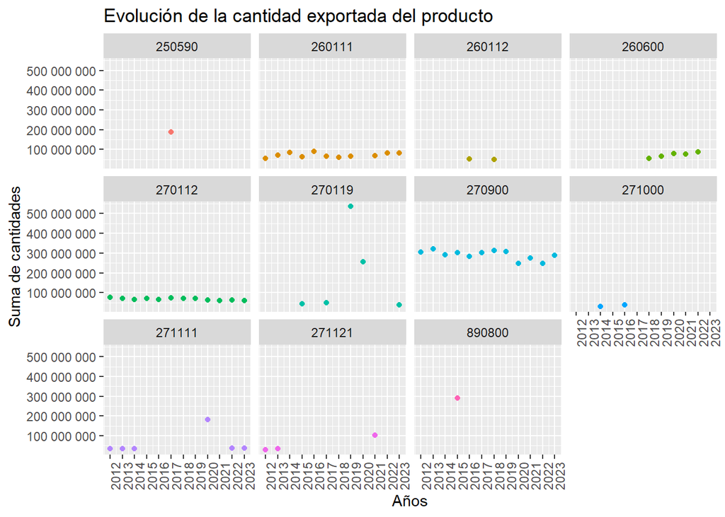

```
## [1] "Top 5 de productos de la región *Américas* en cantidades para cada año"
## # A tibble: 60 × 4
##    Producto Región     Año `Sum. Cant. Export.`
##    <chr>    <chr>    <int>                <dbl>
##  1 270900   Américas  2012           344594451.
##  2 260111   Américas  2012           326461892.
##  3 270112   Américas  2012           117752662.
##  4 260112   Américas  2012            76386682.
##  5 271000   Américas  2012            73661546.
##  6 270900   Américas  2013           363229288.
##  7 260111   Américas  2013           340811224.
##  8 270112   Américas  2013           120137002.
##  9 271000   Américas  2013            74590728.
## 10 260112   Américas  2013            70998358.
## # ℹ 50 more rows
```

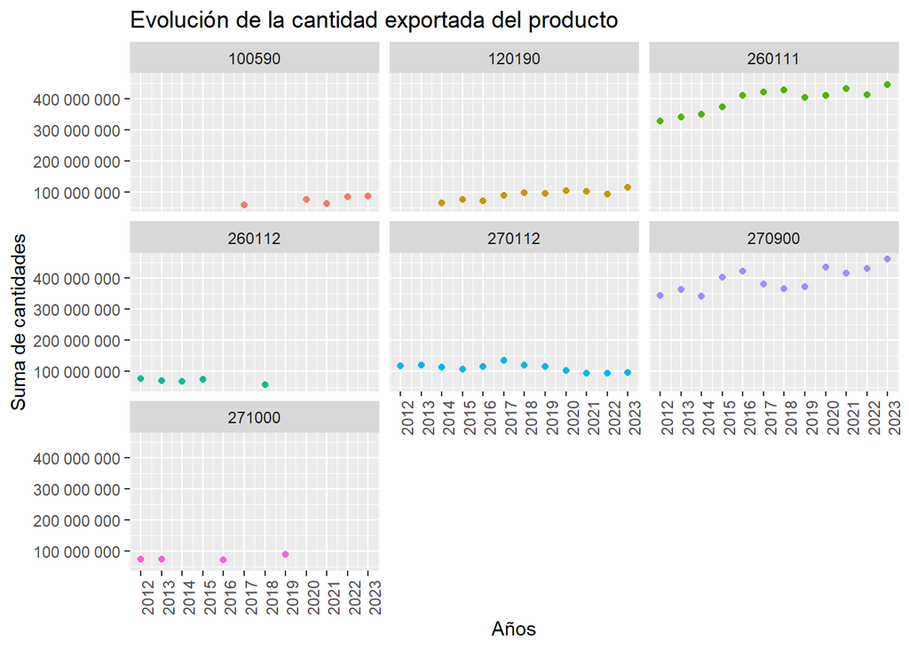

```
## [1] "Top 5 de productos de la región *Asia* en cantidades para cada año"
## # A tibble: 60 × 4
##    Producto Región   Año `Sum. Cant. Export.`
##    <chr>    <chr>  <int>                <dbl>
##  1 270900   Asia    2012          1182601498.
##  2 220190   Asia    2012           793888758.
##  3 271000   Asia    2012           337443840.
##  4 270119   Asia    2012           208837800.
##  5 270112   Asia    2012           206112872.
##  6 270900   Asia    2013           988246931.
##  7 220190   Asia    2013           698892079.
##  8 271000   Asia    2013           321854152.
##  9 270119   Asia    2013           214298219.
## 10 270112   Asia    2013           198680764.
## # ℹ 50 more rows
```

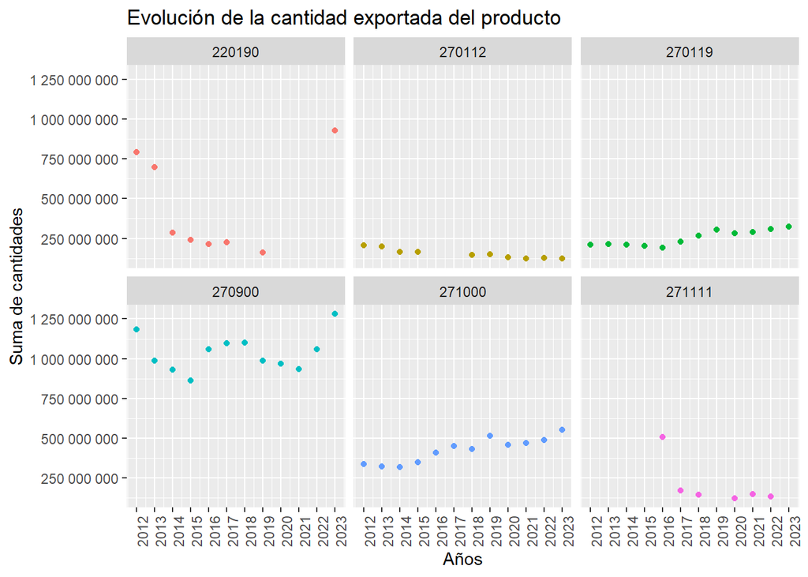

```
## [1] "Top 5 de productos de la región *Europa* en cantidades para cada año"
## # A tibble: 60 × 4
##    Producto Región   Año `Sum. Cant. Export.`
##    <chr>    <chr>  <int>                <dbl>
##  1 271000   Europa  2012           413171701.
##  2 270900   Europa  2012           323646381.
##  3 270112   Europa  2012           124803304.
##  4 271121   Europa  2012           121014569.
##  5 251710   Europa  2012            65420872.
##  6 271000   Europa  2013           425090387.
##  7 270900   Europa  2013           319913473.
##  8 271121   Europa  2013           136961320.
##  9 270112   Europa  2013           128469068.
## 10 251710   Europa  2013            66368513.
## # ℹ 50 more rows
```

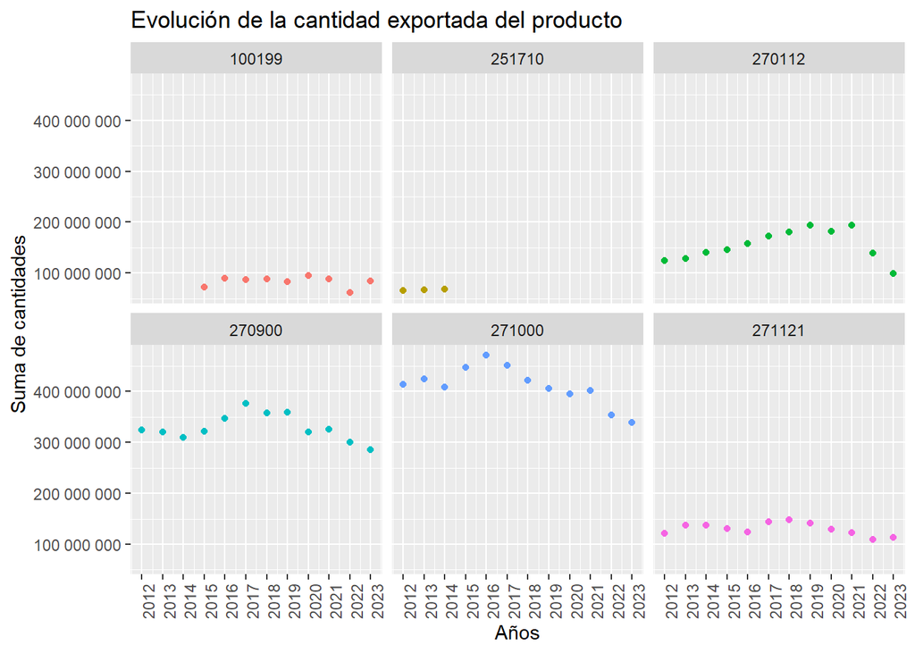

```
## [1] "Top 5 de productos de la región *Oceanía* en cantidades para cada año"
## # A tibble: 60 × 4
##    Producto Región    Año `Sum. Cant. Export.`
##    <chr>    <chr>   <int>                <dbl>
##  1 260111   Oceanía  2012           497186488.
##  2 270112   Oceanía  2012           302192685.
##  3 100199   Oceanía  2012            22663233.
##  4 271111   Oceanía  2012            20376806.
##  5 270900   Oceanía  2012            18332976.
##  6 260111   Oceanía  2013           570519840.
##  7 270112   Oceanía  2013           316687186.
##  8 270119   Oceanía  2013            43146246.
##  9 271111   Oceanía  2013            22156346.
## 10 100199   Oceanía  2013            16942159.
## # ℹ 50 more rows
```

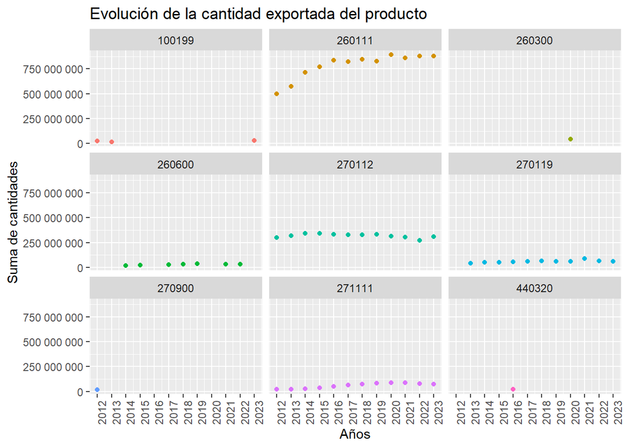

```r
# Iteramos y hallamos el top 5 en cantidades, para cada año, de los productos exportados para las cinco regiones

for (nombre in nombres_regiones$`Region Name`){

  tabla.sum.q.by.k.region <- function(sum.q_by.i, nombre, an){

    tabla_top_5_q = data.frame()

    tabla_resumen_q = data.frame()

      if (!is.na(nombre)) {

      for (a in an){

        top_5_quant <- sum.q_by.i %>%
          group_by(k, `Region Name`, t) %>%
          filter(`Region Name`== nombre, t == a) %>%
          summarise(sum_quants = sum(sum_q, na.rm = T),  .groups = 'drop') %>%
          arrange (-sum_quants) %>% head(sum.v_by.i, n=5L)

        # Los unimos en una sola tabla, correspondiente al año presente

          tabla_top_5_q <- rbind(tabla_top_5_q, top_5_quant)

      graph.top_5_q <- ggplot(tabla_top_5_q, aes(x=t, y=sum_quants, color=k)) +
        geom_point(show.legend = FALSE) + facet_wrap(~k) +
        labs(title = "Evolución de la cantidad exportada del producto") +
        xlab("Años") +  ylab("Suma de cantidades") + scale_x_continuous(breaks = seq(2012, 2023, by = 1)) +
        scale_y_continuous(labels = label_number()) +
        theme(axis.text.x = element_text(angle = 90))

        resumen_top_5_quant <- top_5_quant %>% group_by(`Region Name`) %>%
          summarise(mean_quants = mean(sum_quants, na.rm = T))

        resumen_top_5_quant <- cbind(c(a), resumen_top_5_quant)

        tabla_resumen_q <- rbind(tabla_resumen_q, resumen_top_5_quant)

      }

      colnames(tabla_top_5_q) <- c('Producto','Región','Año','Sum. Cant. Export.')

      print(sprintf("Top 5 de productos de la región *%s* en cantidades para cada año", nombre))

      print(tabla_top_5_q)

      print(graph.top_5_q)
      }
    }

  tabla_top_5_quants <- tabla.sum.q.by.k.region (k_sum.q_by.i, nombre, anios)
  tabla_top_5_quants
}
```

Con los gráficos obtenidos vemos que para las regiones de *África* y *Océania* han habido cierta variedad en los top de productos en relación a las cantidades comercializadas, a diferencia de las demás regiones.

### Precio Implícito

Para hallar un *precio implícito* de cada producto vamos a calcular la relación entre valores monetarios exportados (10^3 **dólares**) y las cantidades en peso exportados (**ton**), por lo que se expresa el precio en 10^3 dólares/toneladas, o simplicando nos quedaría **dólares/kg**

Mostramos un gráfico donde muestre la dispersión de los precios: `sum_v` v.s. `sum_q`para cada producto `k`.

```r
# Tabla que me permite tener el precio implícito considerando la suma de los valores de venta ($) dividiendo la cantidad vendida (kg) por lo que obtenemos un dataframe para cada producto y para cada año.

tabla.precio <- function(vers, an){

  tabla_final <- data.frame()

  # Itero sobre las versiones
    for (v in vers){

  # Itero sobre los años
    for (a in an){

      archivo <- buscar.archivo.simple(anio = a, hs=vers)

      df <- fread(archivo, colClasses = c("k"="character"), showProgress = F,
                  data.table = F)

      # Añadimos a un dataframe la suma de todos los productos, ya sea en valor y en cantidad, agrupados por cada año en un en un solo data.
      suma_q2 <- df %>%
        group_by(k,t) %>% #aqui si 't' para conservar solo un año
        summarise(sum_q = sum(q, na.rm = T), .groups = 'drop')

      suma_v2 <- df %>%
        group_by(k) %>%   #aqui no
        summarise(sum_v = sum(v, na.rm = T), .groups = 'drop')

      tabla_suma_q2_v2 <- suma_q2 %>%left_join(.,suma_v2, by=c('k'='k'))

      # Por lo que tenemos dos tablas, la suma de valores y la de suma de               cantidades
      tabla_final <- rbind(tabla_final, tabla_suma_q2_v2)
      }
    }

    # Obtenemos una tabla con la información del precio para todos los años
      tabla_final <- tabla_final %>%
        #distinct(k, sum_q, sum_v, t) %>%
        mutate (p_imp = sum_v/sum_q) %>%
        left_join(.,codes.productos , by = c(k="code")) %>%
        select(k, t, sum_q, sum_v, p_imp, description)

  return(tabla_final)
}

tabla.precio.imp <- tabla.precio(version, anios) %>% filter(sum_q > 0)
tabla.precio.imp
```

```
## # A tibble: 62,373 × 6
##    k          t    sum_q    sum_v  p_imp description
##    <chr>  <int>    <dbl>    <dbl>  <dbl> <chr>
##  1 010121  2012   25283. 1166505. 46.1   Horses: live, pure-bred breeding anima…
##  2 010129  2012   73596.  948005. 12.9   Horses: live, other than pure-bred bre…
##  3 010130  2012    3558.    3176.  0.893 Asses: live
##  4 010190  2012    3042.   40006. 13.2   Mules and hinnies: live
##  5 010221  2012  269502. 1438843.  5.34  Cattle: live, pure-bred breeding anima…
##  6 010229  2012 2031103. 6260329.  3.08  Cattle: live, other than pure-bred bre…
##  7 010231  2012    5998.    6163.  1.03  Buffalo: live, pure-bred breeding anim…
##  8 010239  2012   61130.   58859.  0.963 Buffalo: live, other than pure-bred br…
##  9 010290  2012 1016735. 2253625.  2.22  Bovine animals: live, other than cattl…
## 10 010310  2012   54556.  258817.  4.74  Swine: live, pure-bred breeding animals
## # ℹ 62,363 more rows
```

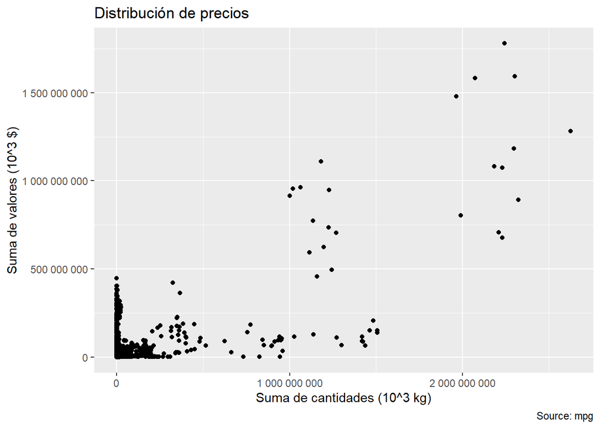

```r
ggplot(data = tabla.precio.imp, mapping = aes(x = sum_q, y = sum_v)) +
  geom_point() +
  labs(title="Distribución de precios",
         caption="Source: mpg",
         x="Suma de cantidades (10^3 kg)",
         y="Suma de valores (10^3 $)") +
  scale_y_continuous(labels = label_number()) +
  scale_x_continuous(labels = label_number())
```

Tabla que muestra el promedio del precio implícito de cada producto a lo largo de todos los años

```r
tabla.pr.imp.mean <- tabla.precio.imp %>%
  group_by(k, description) %>%
  summarise(mean.p_imp = mean(p_imp, na.rm = T),  .groups = 'drop')

colnames(tabla.pr.imp.mean) <- c('Cod. Producto', 'Descripción','Prom. Precio Implícito ($/kg)')

tabla.pr.imp.mean
```

```
## # A tibble: 5,198 × 3
##    `Cod. Producto` Descripción                            Prom. Precio Implíci…¹
##    <chr>           <chr>                                                   <dbl>
##  1 010121          Horses: live, pure-bred breeding anim…                  64.4
##  2 010129          Horses: live, other than pure-bred br…                  17.9
##  3 010130          Asses: live                                              1.41
##  4 010190          Mules and hinnies: live                                  4.64
##  5 010221          Cattle: live, pure-bred breeding anim…                   4.08
##  6 010229          Cattle: live, other than pure-bred br…                   2.96
##  7 010231          Buffalo: live, pure-bred breeding ani…                   1.86
##  8 010239          Buffalo: live, other than pure-bred b…                   3.12
##  9 010290          Bovine animals: live, other than catt…                   2.80
## 10 010310          Swine: live, pure-bred breeding anima…                   4.84
## # ℹ 5,188 more rows
## # ℹ abbreviated name: ¹`Prom. Precio Implícito ($/kg)`
```

¿Cual es precio promedio implícito más costoso?

```r
pr.imp_max <- which.max(tabla.pr.imp.mean$'Prom. Precio Implícito ($/kg)')

cat("El valor máximo es el producto con código:", tabla.pr.imp.mean$'Cod. Producto'[pr.imp_max], 'correspondiente al producto', tabla.pr.imp.mean$'Descripción'[pr.imp_max], '; cuyo precio medio es', tabla.pr.imp.mean$'Prom. Precio Implícito ($/kg)'[pr.imp_max], '$/kg', "\n")
```

```
## El valor máximo es el producto con código: 710239 correspondiente al producto Diamonds: non-industrial, (other than unworked or simply sawn, cleaved or bruted), but not mounted or set ; cuyo precio medio es 476969.6 $/kg
```

¿Cual es precio promedio implícito más barato?

```r
pr.imp_min <- which.min(tabla.pr.imp.mean$'Prom. Precio Implícito ($/kg)')

cat("El valor mínimo es el producto con código:", tabla.pr.imp.mean$'Cod. Producto'[pr.imp_min], 'correspondiente al producto', tabla.pr.imp.mean$'Descripción'[pr.imp_min], '; cuyo precio medio es', tabla.pr.imp.mean$'Prom. Precio Implícito ($/kg)'[pr.imp_min], '$/kg')
```

```
## El valor mínimo es el producto con código: 220190 correspondiente al producto Waters: other than mineral and aerated, (not containing added sugar or other sweetening matter nor flavoured), ice and snow ; cuyo precio medio es 0.006205336 $/kg
```

Evolución de precio de un producto `k` a lo largo de de los años

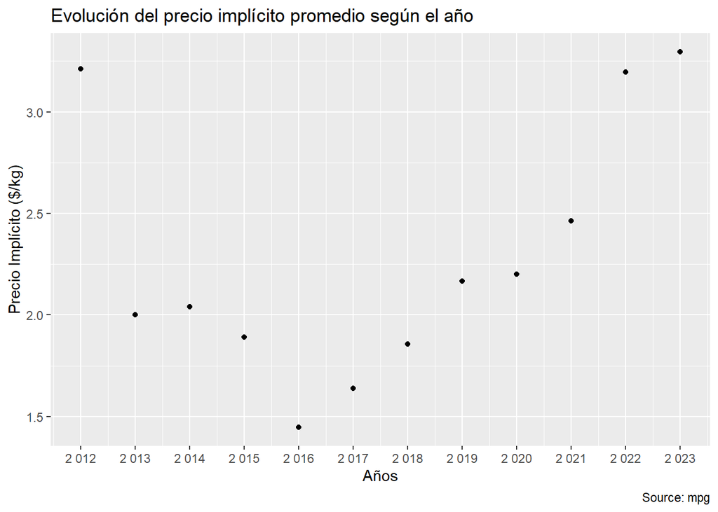

```r
####### Carga de datos ########
cod.producto <- '290329'
###############################

tabla.product <- tabla.precio.imp %>% filter(k == cod.producto)

ggplot(data = tabla.product, mapping = aes(x = t, y = p_imp)) +
  geom_point() +
  labs(title="Evolución del precio implícito promedio según el año",
         #subtitle = ,
         caption="Source: mpg",
         x="Años",
         y="Precio Implícito ($/kg)") +
  scale_y_continuous(labels = label_number()) +
  scale_x_continuous(labels = label_number(), breaks = seq(2012, 2023, by = 1))
```